# Coursera Practical Machine Learning Project

Anna H

2025-03-05

### Introduction

This report details the development of a machine learning model for activity recognition using data from accelerometers on the belt, forearm, arm, and dumbbell of 6 participants. The goal was to predict the manner in which they performed barbell lifts, classified into five categories (as the *classe* variable):

- A - exactly according to the specification
- B - throwing the elbows to the front
- C - lifting the dumbbell only halfway
- D - lowering the dumbbell only halfway
- E - throwing the hips to the front

### Data Preparation and Exploratory Analysis

Our first step was to read in the dataset, to clean it and to make sure we only use the features that are helpful for our predictions. The [documentation for the original project](http://web.archive.org/web/20170519033209/http://groupware.les.inf.puc-rio.br/public/papers/2013.Velloso.QAR-WLE.pdf) (p.3) mentions 40 such variables out of the total 154 columns. So, we used those 40 features as a starting point for our classification.

```r
# select only important features (as per paper describing the data)
importantFeatures <- c(
        "roll_belt", "pitch_belt", "yaw_belt", "total_accel_belt",
        "accel_belt_x", "accel_belt_y", "accel_belt_z",
        "gyros_belt_x", "gyros_belt_y", "gyros_belt_z",
        "magnet_belt_x", "magnet_belt_y", "magnet_belt_z",
        "roll_arm", "pitch_arm", "yaw_arm", "total_accel_arm",
        "magnet_arm_x", "magnet_arm_y", "magnet_arm_z",
        "roll_dumbbell", "pitch_dumbbell", "yaw_dumbbell", "total_accel_dumbbell",
        "accel_dumbbell_x", "accel_dumbbell_y", "accel_dumbbell_z",
        "gyros_dumbbell_x", "gyros_dumbbell_y", "gyros_dumbbell_z",
        "magnet_dumbbell_x", "magnet_dumbbell_y", "magnet_dumbbell_z",
        "roll_forearm", "pitch_forearm", "yaw_forearm", "total_accel_forearm",
        "gyros_forearm_x", "gyros_forearm_y", "gyros_forearm_z")
```

To get an idea of the distribution of the *classe* variable that we wanted to predict, we graphed the dataset, and we checked that there are no rows left with missing information. And we see that there are 0 such rows out of a total of 19,622.

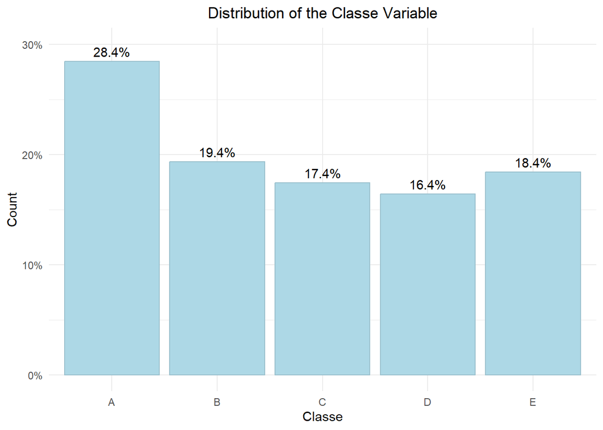

After setting a seed for reproducibility, we separated the *classe* variable from the dataset and split all of the data (the main dataset with the measurements and the one containing the classe information) into matching training and testing sets. The training dataset was set to be 70% of the original (at 13,737 total observations) and the rest (5,885 total observations) was left for model testing.

Next, we took a look at the variability within our data by looking at the coefficients of variation (CV) for each feature to see how large or small it was. We saw that there were several variables that had extreme (>1,000 or 10 times the mean) coefficients of variation, which suggested extreme amounts of variation within the dataset.

```
## [1] "pitch_belt, gyros_belt_x, yaw_arm, yaw_dumbbell, gyros_dumbbell_x, gyros_dumbbell_y, gyros_dumbbell_z, gyros_forearm_y, gyros_forearm_z"
```

The median absolute deviation (MAD) values, which are less sensitive to outliers than CVs also showed quite a bit of variability as can be seen on the chart below (one extreme outlier has been left off the chart - magnet_arm_x with a value of 618.24).

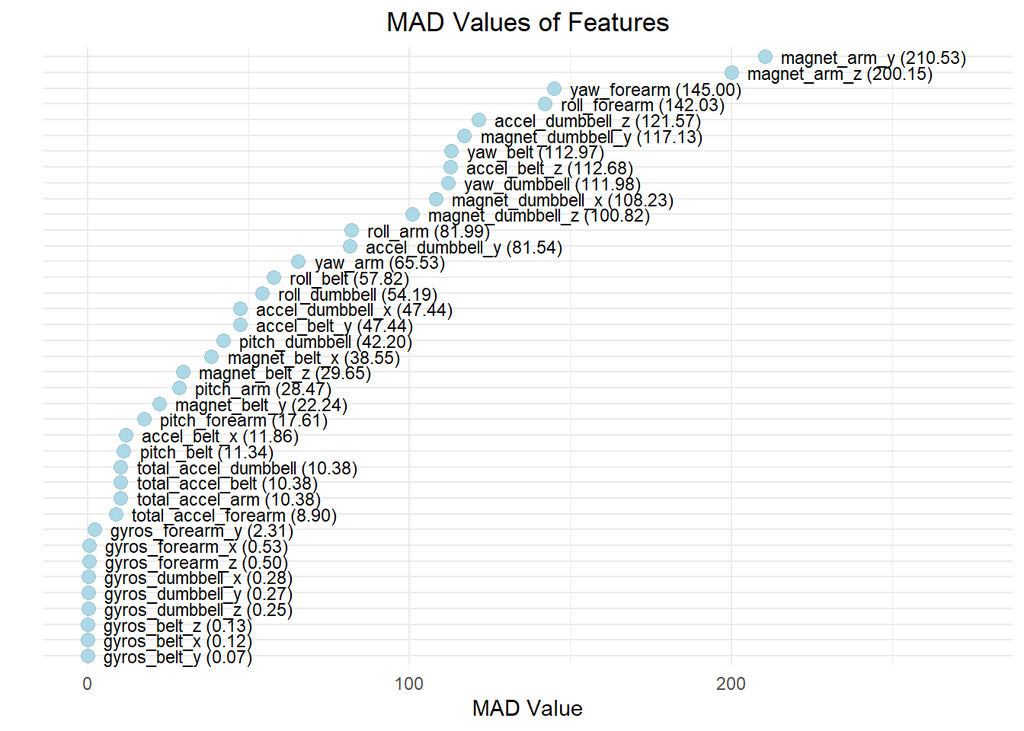

### Model Building

#### Algorithm Selection

Since this is a classification problem, we used a decision tree approach to get our *classe* prediction. However, a basic decision tree creates only one tree and may not capture the necessary relationships and may lead to a low level of accuracy. Therefore, we decided to utilize an instance of bagging, which allowed us to train multiple models to get a better result. In this case, we chose a **random forest** method for the final model creation due its strong predictive performance and its ability to capture non-linear relationships between variables without explicit specification of their relationships. Random forests are also known to help prevent overfitting, which is likely to happen when there’s high variance, as is the case with this data. This method also provides measures of feature importance that can potentially reduce the number of variables needed.

#### Cross-Validation and Hyperparameter Tuning

An important step in training a good model is to select the appropriate tuning parameters. A grid search with 10-fold k-fold cross-validation was done to tune the hyperparameters for the following values:

- number of trees to grow (*ntree* was evaluated at values of 100, 500 and 1000
- number of features to randomly sample at each tree split (*mtry* was evaluated at 6, 13 and 20)
- sample tree sizes (bootstrap size was evaluated at 500, 1000 and 1500)

For each combination, stratified sampling for bootstrapping was used and the model’s accuracy was evaluated using cross-validation. Unfortunately, this negatively affected the processing time. The best parameters were selected as follows:

- number of features - 13
- number of trees - 1000
- sample tree size - 1500

### Model Training and Evaluation

It was not practical to use the whole training set due to its size, so, next, we used the selected best parameters to train a random forest model on a randomly selected part of the training set (that consisted of 1500 data points).

```r
        trainIndices <- createDataPartition(trainingClasse,
                                      p = bootstrapValue / length(trainingClasse),
                                      list = FALSE)
        bootstrapTraining <- training[trainIndices, ]
        bootstrapClasse <- trainingClasse[trainIndices]

        basicModel <- train(x = bootstrapTraining,
               y = bootstrapClasse,
               method = "rf",
               trControl = trainControl(method = "cv", number = 10),
               metric = "Accuracy",
               tuneGrid = expand.grid(.mtry = mtry),
               ntree = ntree)
```

After making predictions the model was evaluated by looking at its confusion matrix (see below).

Overall, the model appeared to have a 93.72% accuracy, which means that it correctly classified most of the data. The Cohen’s kappa for our model was 0.92, a value very close to 1. This means that the agreement between predicted and actual classes is not likely to have happened by chance.

The average of the F1 scores across the classes was 93.32%, which also suggests a high prediction quality, and that is also confirmed by the weighted-average of the F1 scores (93.72%).

```
## Confusion Matrix and Statistics
##
##           Reference
## Prediction    A    B    C    D    E
##          A 3831  127   11   20    4
##          B   17 2376  112   28   30
##          C   30  126 2211  155   34
##          D   20   16   30 2017   18
##          E    8   13   32   32 2439
##
## Overall Statistics
##
##                Accuracy : 0.9372
##                  95% CI : (0.933, 0.9412)
##     No Information Rate : 0.2843
##     P-Value [Acc > NIR] : < 0.00000000000000022
##
##                   Kappa : 0.9205
##
##  Mcnemar's Test P-Value : < 0.00000000000000022
##
## Statistics by Class:
##
##                      Class: A Class: B Class: C Class: D Class: E
## Sensitivity            0.9808   0.8939   0.9228   0.8956   0.9659
## Specificity            0.9835   0.9831   0.9696   0.9927   0.9924
## Pos Pred Value         0.9594   0.9270   0.8650   0.9600   0.9663
## Neg Pred Value         0.9923   0.9748   0.9835   0.9798   0.9923
## Precision              0.9594   0.9270   0.8650   0.9600   0.9663
## Recall                 0.9808   0.8939   0.9228   0.8956   0.9659
## F1                     0.9700   0.9102   0.8930   0.9267   0.9661
## Prevalence             0.2843   0.1935   0.1744   0.1639   0.1838
## Detection Rate         0.2789   0.1730   0.1610   0.1468   0.1775
## Detection Prevalence   0.2907   0.1866   0.1861   0.1529   0.1837
## Balanced Accuracy      0.9822   0.9385   0.9462   0.9442   0.9792
```

To confirm that the model was not overfitting, we tested its performance on the testing data that we separated from the original dataset earlier. With this unseen data we confirmed that the model was still performing well across all classes achieving high accuracy (93.13%). The minor difference of approximately 0.58% compared to the training set’s accuracy suggests minimal overfitting. The model also has a strong kappa (0.913) and the average F1 of 92.68%, which still shows a strong agreement between predicted and actual classes and a good prediction quality.

The model still struggles the most with correctly identifying Class B instances (with lowest sensitivity of all classes at 87.77%) and is least confident in its Class C predictions (lowest precision at 84.48%). Although these figures are slightly below the metrics from the training set, they are high enough to show that the model is still performing well even on unseen data.

When we create an ROC curve for both the training and testing set results we can also see that the area under the curve for each of the classes in both sets is very close the the perfect measure of 1, confirming that the model is quite good at distinguishing between classes across various thresholds.

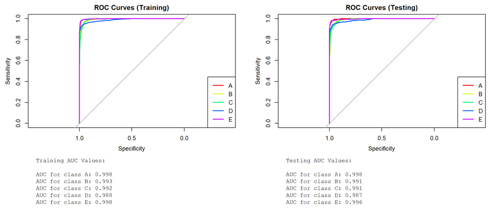

#### Expected Out-of-Sample Error

Given the test set accuracy of 93.13%, the expected out-of-sample error is approximately 1-accuracy = 6.87%. This estimate is based on the test set performance, which is a bit lower than the training set accuracy. However, it’s important to note that this error rate might still be a little optimistic, and the performance on entirely new data could be slightly lower.